# Exploratory Data Analysis-BreakHis Dataset

#### February 23,2019

# **[1] About Data**

The dataset which we are going to use is BreakHis dataset caontainin 7909 histopathical breast cancer sample images from 82 patients respectively.

**REPRESENTATION OF DATASET IN PROJECT IS AS FOLLOWS-**

*1. Cancer Class*

**1.1. Benign**

This Class is represented by Integer-1

**1.2. Malignant**

This Class is represented by Integer-2

**2. Cancer Type**

**2.1 Benign-A**

Benign-A represents Adenosis.This Class is represented by Integer-11

**2.2 Benign-FA**

Benign-FA represents Fibro Adenoma.This Class is represented by Integer-12

**2.3 Benign-TA**

Benign-TA represents Tubulor Adenoma.This Class is represented by Integer-13

**2.4 Benign-PT**

Benign-PT represents Phyllodes Tumor.This Class is represented by Integer-14

**2.5. Malignant-DC**

Malignant-DC represents Ductol Carinoma.This Class is represented by Integer-21

**2.6. Malignant-LC**

Malignant-LC represents Lobular Carinoma.This Class is represented by Integer-22

**2.7. Malignant-MC**

Malignant-Mc represents Mucious Carinoma.This Class is represented by Integer-23

**2.8. Malignant-PC**

Malignant-PC represents Pappillary Carinoma.This Class is represented by Integer-24

*3. Magnification*

**3.1. 40X - 40**

**3.2. 100X - 100**

**3.3. 200X - 200**

**3.4. 400X - 400**

**Note -**

After Each visualization some counts are represented for elaborations of plots which are used for distribution.

# **Pre-Exploratory Data Analysis**

**Import Library**

```python
import pandas as pd
import numpy as np
import seaborn as sb
sb.set(style="darkgrid")
import matplotlib.pyplot as plt
```

**Loading Numpy Array**

```python
# Train Arrays
data_cancerclass_train=np.load("train/data_cancerclass_train.npy")
data_cancertype_train=np.load("train/data_cancertype_train.npy")
data_mag_train=np.load("train/data_mag_train.npy")
# Test Arrays
data_cancerclass_test=np.load("test/data_cancerclass_test.npy")
data_cancertype_test=np.load("test/data_cancertype_test.npy")
data_mag_test=np.load("test/data_mag_test.npy")
```

# **[2] Train Arrays Visualization**

```python
train_df=pd.DataFrame({'Cancer Class':data_cancerclass_train,
                      'Cancer Type':data_cancertype_train,
                      'Magnification':data_mag_train})
```

### **[2.1] Cancer Class**

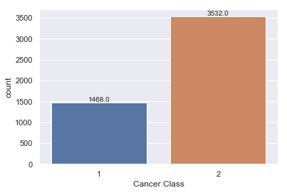

```python
ax = sb.countplot(x="Cancer Class", data=train_df)
fig=ax.get_figure()
fig.savefig("Train Cancer Class.png")
for p in ax.patches:
    x=p.get_bbox().get_points()[:,0]
    y=p.get_bbox().get_points()[1,1]
    ax.annotate(y,(x.mean(), y),ha='center', va='bottom')
```

```python
print(train_df.groupby("Cancer Class").count())
```

```
              Cancer Type  Magnification
Cancer Class
1                    1468           1468
2                    3532           3532
```

### **[2.3] Cancer Type**

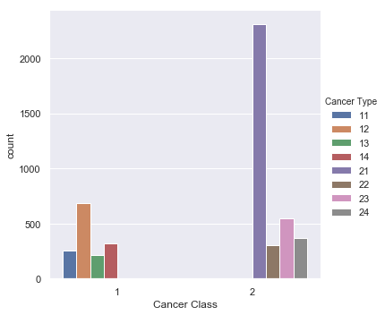

```python
ax = sb.catplot(x="Cancer Class",hue="Cancer Type", data=train_df,kind="count")
ax.savefig("Train Cancer Class with cancer type.png")
```

```python
print(train_df.groupby("Cancer Type").count())
```

```
             Cancer Class  Magnification
Cancer Type
11                    252            252
12                    682            682
13                    217            217
14                    317            317
21                   2312           2312
22                    302            302
23                    547            547
24                    371            371
```

### **[2.3] Magnification**

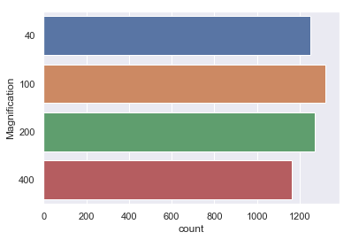

```python
ax=sb.countplot(y="Magnification", data=train_df)
fig=ax.get_figure()
fig.savefig("Train Magnification.png")
```

```python
print(train_df.groupby("Magnification").count())
```

```
               Cancer Class  Cancer Type
Magnification
40                     1248         1248
100                    1320         1320
200                    1268         1268
400                    1164         1164
```

### **[2.4] Cancer Class Data Distribution**

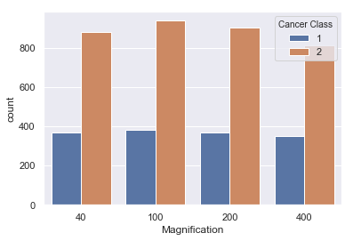

```python
ax=sb.countplot(x="Magnification",hue="Cancer Class", data=train_df)
fig=ax.get_figure()
fig.savefig("Train Magnification in Train Numpy.png")
```

```python
print(train_df.groupby(["Cancer Class","Magnification"]).count())
```

```
                            Cancer Type
Cancer Class Magnification
1            40                     369
             100                    382
             200                    367
             400                    350
2            40                     879
             100                    938
             200                    901
             400                    814
```

### **[2.5] Train Data Distribution**

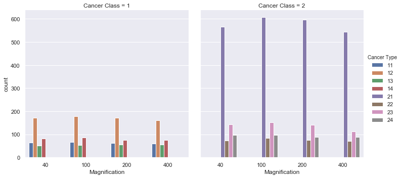

```python
ax= sb.catplot(x="Magnification", hue="Cancer Type", col="Cancer Class",data=train_df, kind="count")
ax.savefig("Train Cancer Type with Magnification using Cancer Class.png")
```

```python
print(train_df.groupby(["Cancer Type","Magnification"]).count())
```

```
                           Cancer Class
Cancer Type Magnification
11          40                       64
            100                      66
            200                      63
            400                      59
12          40                      172
            100                     177
            200                     172
            400                     161
13          40                       51
            100                      54
            200                      56
            400                      56
14          40                       82
```

[output cut: 19 more lines]

# **[3] Test Arrays Visualization**

```python
test_df=pd.DataFrame({'Cancer Class':data_cancerclass_test,
                      'Cancer Type':data_cancertype_test,
                      'Magnification':data_mag_test})
```

### **[3.1] Cancer Class**

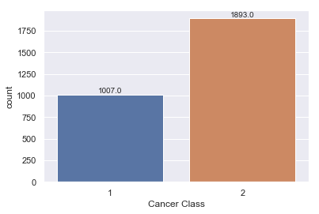

```python
ax = sb.countplot(x="Cancer Class", data=test_df)
fig=ax.get_figure()
fig.savefig("Test Cancer Class.png")
for p in ax.patches:
    x=p.get_bbox().get_points()[:,0]
    y=p.get_bbox().get_points()[1,1]
    ax.annotate(y,(x.mean(), y),ha='center', va='bottom')
```

```python
print(test_df.groupby("Cancer Class").count())
```

```
              Cancer Type  Magnification
Cancer Class
1                    1007           1007
2                    1893           1893
```

### **[3.2] Cancer Type**

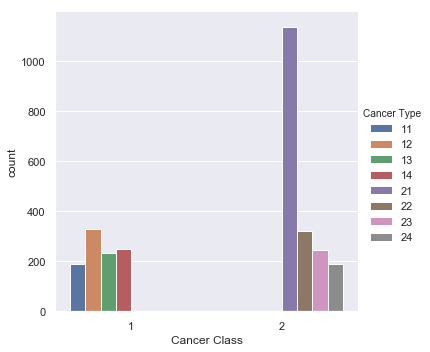

```python
ax = sb.catplot(x="Cancer Class",hue="Cancer Type", data=test_df,kind="count")
ax.savefig("Test Cancer Class with cancer type.png")
```

```python
print(test_df.groupby("Cancer Type").count())
```

```
             Cancer Class  Magnification
Cancer Type
11                    191            191
12                    331            331
13                    235            235
14                    250            250
21                   1138           1138
22                    323            323
23                    244            244
24                    188            188
```

### **[3.3] Cancer Class Maginification**

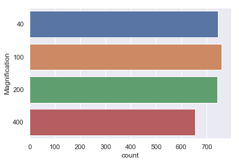

```python
ax=sb.countplot(y="Magnification", data=test_df)
fig=ax.get_figure()
fig.savefig("Test Magnification.png")
```

```python
print(test_df.groupby("Magnification").count())
```

```
               Cancer Class  Cancer Type
Magnification
40                      745          745
100                     759          759
200                     743          743
400                     653          653
```

### **[3.4] Cancer Class Data Distribution**

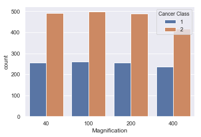

```python
ax=sb.countplot(x="Magnification",hue="Cancer Class", data=test_df)
fig=ax.get_figure()
fig.savefig("Test Magnification in Test Numpy.png")
```

```python
print(test_df.groupby(["Cancer Class","Magnification"]).count())
```

```
                            Cancer Type
Cancer Class Magnification
1            40                     255
             100                    261
             200                    255
             400                    236
2            40                     490
             100                    498
             200                    488
             400                    417
```

### **[3.5] Test Data Distribution**

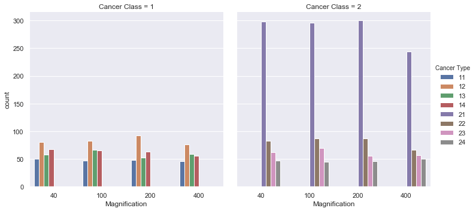

```python
ax= sb.catplot(x="Magnification", hue="Cancer Type", col="Cancer Class",
...                 data=test_df, kind="count");
ax.savefig("Test Cancer Type with Magnification using Cancer Class.png")
```

```python
print(test_df.groupby(["Cancer Type","Magnification"]).count())
```

```
                           Cancer Class
Cancer Type Magnification
11          40                       50
            100                      47
            200                      48
            400                      46
12          40                       80
            100                      83
            200                      92
            400                      76
13          40                       58
            100                      66
            200                      52
            400                      59
14          40                       67
```

[output cut: 19 more lines]

# **Post-Exploratory Data Analysis**

After the dataset is retrived, it was passed through some Deep-Learning Algorithms for feature Extraction.The Algorithms are known as Deep Convolution Neural Networks.

*The Used CNN's are as follows*

**1. VGG16**

**2. VGG19**

**3. Xception**

**4. ResNet50**

**5. InceptionV3**

**6. InceptionResNetV2**

The Dataset was distributed as 5000 Train Samples,2900 Test Samples and Randomly 9 Images were removed for the checking of model.